# [CoalSVModel v3.1](https://coalsvm.github.io) Documentation

This documentation covers the capabilities of CoalSVM v3.1. In this section, flowchart of the software is introduced as well as all interfaces with demo data. Flowchart of CoalSVModel is given in Figure 1.

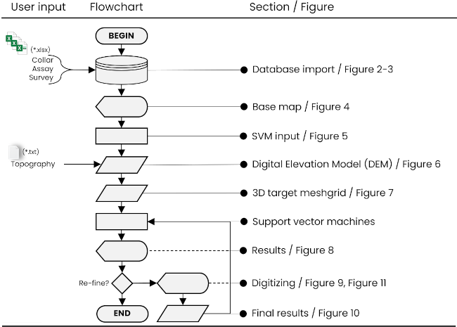

Figure 1: Flowchart of CoalSVModel

The software consists of a total of 8 interfaces. Each interface is presented in this documentation on the tabs located below. The interface names (and section headers) are listed below: **Database import**, **Base map**, **SVM input**, **Digital Elevation Model (DEM)**, **3D target meshgrid**, **Results**, **Digitizing**, and **Final results**.

In addition to these, the export and re-run options in results are introduced in the tabs **Export option** and **Re-run option**, respectively.

# Input files

In **Digital Elevation Model (DEM)** interface, user must load a topography point cloud. An illustrative example and description is given under **DEM file & content** tab.

## Database files & their contents

### Collar

In table below, a portion of collar input file is given. In this case, only first 5 drillholes are included in the table. Mandatory fields in this type of file are drillhole ID, Y (Northing), X (Easting), Z (Elevation), and maximum depth.

| DRILLHOLE_id | Y | X | Z | MAX_DEPTH |
| --- | --- | --- | --- | --- |
| BH007 | 2184 | 7622 | 505.61 | 390.2 |
| BH012 | 2347 | 8645 | 586.88 | 311.35 |
| BH014 | 2390 | 7775 | 470.29 | 352.8 |
| BH016 | 2703 | 7141 | 491.64 | 537.2 |
| BH017 | 2246 | 8260 | 535.67 | 428.4 |

### Assay

Assay file represents coal quality variable analysis. In below example file, MOISTURE: moisture content, ASH: ash content, S: sulfur, and LHV: lower heating values of 5 drillholes are given in depth intervals (FROM and TO). NA entries indicate blank cells.

There are 4 mandatory fields in assay file. They are drillhole id, depth from, depth to, and at least one attribute.

| DRILLHOLE_id | DEPTH_FROM | DEPTH_TO | MOISTURE | ASH | S | LHV |
| --- | --- | --- | --- | --- | --- | --- |
| BH007 | 0 | 105 | NA | NA | NA | NA |
| BH007 | 105 | 183 | NA | NA | NA | NA |
| BH007 | 183 | 251 | NA | NA | NA | NA |
| BH007 | 251 | 349.9 | NA | NA | NA | NA |
| BH007 | 349.9 | 353 | 12.39 | 11.08 | 0.77 | 5053 |
| BH007 | 353 | 355.2 | 14.07 | 10.84 | NA | 5004 |
| BH007 | 355.2 | 357.2 | 11.74 | 26 | NA | 3931 |
| BH007 | 357.2 | 359.7 | 13.7 | 10.99 | 1.55 | 5031 |
| BH007 | 359.7 | 364.2 | 11.46 | 7.35 | NA | 5459 |
| BH007 | 364.2 | 368.3 | 12.86 | 10.83 | 2.42 | 5112 |
| BH007 | 368.3 | 369.55 | 16.48 | 27.16 | NA | 3668 |
| BH007 | 369.55 | 369.7 | 25 | 75 | NA | 1 |
| BH007 | 369.7 | 373.4 | 15.04 | 24.26 | NA | 3944 |
| BH007 | 373.4 | 376.5 | 12.53 | 44.79 | 1.14 | 2443 |
| BH007 | 376.5 | 378.6 | 13.6 | 48 | NA | 2169 |
| BH007 | 378.6 | 379 | 25 | 75 | NA | 1 |
| BH007 | 379 | 379.55 | 12.49 | 29.94 | NA | 3652 |
| BH007 | 379.55 | 380.85 | 9.28 | 43.83 | NA | 2924 |
| BH007 | 380.85 | 381.2 | 25 | 75 | NA | 1 |
| BH007 | 381.2 | 382.6 | 12.28 | 54.42 | NA | 1802 |
| BH007 | 382.6 | 384.3 | 13.52 | 56.74 | NA | 1479 |
| BH007 | 384.3 | 390.2 | NA | NA | NA | NA |
| BH012 | 0 | 88.2 | NA | NA | NA | NA |
| BH012 | 88.2 | 88.6 | NA | NA | NA | NA |
| BH012 | 88.6 | 90.5 | NA | NA | NA | NA |
| BH012 | 90.5 | 91.7 | NA | NA | NA | NA |
| BH012 | 91.7 | 93.5 | NA | NA | NA | NA |
| BH012 | 93.5 | 94.3 | NA | NA | NA | NA |
| BH012 | 94.3 | 212 | NA | NA | NA | NA |
| BH012 | 212 | 212.5 | NA | NA | NA | NA |

[output cut: 104 more lines]

### Survey

Survey file is related to the path of the drillholes. There are four mandatory fields in this file. They are drillhole id, measured depth, dip, and azimuth. In the illustrative example below, drillhole “BH007” has five different dipping and azimuth records while all other drillhole paths are recorded as vertical (i.e. dip= -90°).

| DRILLHOLE_id | DEPTH | DIP | AZIMUTH |
| --- | --- | --- | --- |
| BH007 | 0 | -88.8 | 309.6 |
| BH007 | 6 | -88.8 | 309.6 |
| BH007 | 38 | -89 | 308.2 |
| BH007 | 68 | -88.9 | 285.9 |
| BH007 | 390.2 | -88.8 | 321.7 |
| BH012 | 311.35 | -90 | 0 |
| BH014 | 352.8 | -90 | 0 |
| BH016 | 537.2 | -90 | 0 |
| BH017 | 428.4 | -90 | 0 |

## DEM file & content

DEM file, which is basically a topography point cloud file, is second input after database files. In the table below, a portion of an example DEM file is shown. The DEM is in Fixed-format ASCII.

| 4350 | 8968.758 | 340 |
| --- | --- | --- |
| 4344.311 | 8960.365 | 340 |
| 4301.017 | 8865.362 | 340 |
| 4286.984 | 8993.738 | 340 |
| 4322.676 | 9096.142 | 340 |
| 4350 | 9189.418 | 340 |

# CoalSVModel Interfaces

## Database import

User starts the program by setting the working directory. This directory contains database files and Digital Elevation Model (DEM). Every output of CoalSVModel such as error and validation reports, exported files, and results are saved in this directory.

Mandatory fields in the collar file are as follows:

- Hole id: Name of each borehole,
- Easting(X): Easting coordinates of boreholes,
- Northing(Y): Northing coordinates of boreholes,
- Elevation(Z): Elevation coordinates of boreholes, and
- Depth: Total length of the boreholes.

In the database collar import, all fields are checked and validated for errors and the user is notified with a report file. All fields in this import phase except hole id must be numeric, therefore, validation algorithm only reports whether coordinate values and maximum depth are numeric or not. In Hole id field, duplicates are reported. Also, blank entries are regarded as an error. The assay file cannot be loaded until all the collar fields have been verified and successfully imported.

Assay file should be in the form of intervals. This requires each assay is defined row-wise with respect to the from and to depths for the corresponding boreholes. Mandatory fields in assay file import are as follows:

- Hole id: The connection of the Assay file with the boreholes in the Collar file is achieved by matching the hole id column in assay file,
- From: Indicates starting depth of sample that is analyzed,
- To: end depth of sample. (i.e., difference (To-From is the sample length of corresponding assay entry), and
- Attribute: analyze value of the variable at interest.

Verification, validation, and error report generation process of the Assay file is more complex and diverse compared to the Collar file. Potential errors and verification routines can be listed for each mandatory field are as follows:

- Hole id: Boreholes that exist in the assay file but not in the collar file. Same applies for the other way around. Blank entries.
- From: Nonnumerical or blank entries. Values that exceed “Depth” of corresponding borehole. Values higher than “To” values of corresponding assay entry. Duplicated “From” values.
- To: Nonnumerical or blank entries. Values that exceed “Depth” of corresponding borehole. Values lower than “From” values of corresponding assay entry. Overlapping From – To intervals. Duplicated “To” values.
- Attribute: Nonnumerical entries. The blank entries are listed as warning, not regarded as an error.

Figure 2 and Figure 3 shows interfaces and column matching of Collar-Assay and Survey files, respectively.

[figure not shown]

Figure 2: Data Import for collar and assay interface of CoalSVModel

[figure not shown]

Figure 3: Data Import for survey interface of CoalSVModel

Back to top

## Base map

[figure not shown]

Figure 4: Basemap interface of CoalSVModel

Back to top

## SVM input

[figure not shown]

Figure 5: SVM input interface of CoalSVModel

Back to top

## Digital Elevation Model (DEM)

[figure not shown]

Figure 6: DEM interface of CoalSVModel

Back to top

## 3D target meshgrid

[figure not shown]

Figure 7: 3D target meshgrid interface of CoalSVModel

Back to top

## Results

[figure not shown]

Figure 8: Results interface of CoalSVModel

Back to top

## Digitizing

[figure not shown]

Figure 9: Digitising interface of CoalSVModel

Back to top

## Final results

[figure not shown]

Figure 10: Final results interface of CoalSVModel

Back to top

## Export option

[figure not shown]

Figure 11: Export option in results

## Re-run option

[figure not shown]

Figure 12: Re-run of CoalSVModel